# VLM Wrong Predictions: attr_bridge_type [both_right]

Actual: Beam

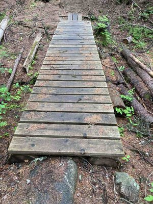

52810__AST_EX_20220707_123505.jpeg

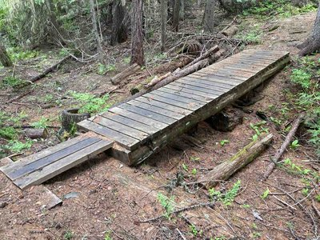

52826__AST_EX_20220707_123534.jpeg

Asset 49060 4 images

Predicted: VLM: Beam | DINOv3: Beam (conf: N/A)

Actual: Beam

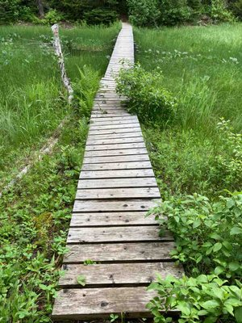

52793__AST_EX_20220707_124156.jpeg

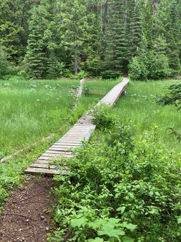

52796__AST_EX_20220707_124145.jpeg

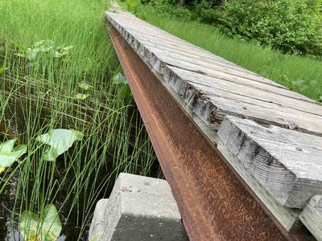

52797__AST_EX_20220707_124315.jpeg

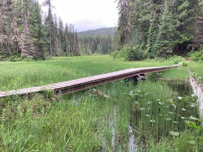

52813__AST_EX_20220707_124357.jpeg

Asset 49061 2 images

Predicted: VLM: Beam | DINOv3: Beam (conf: N/A)

Actual: Beam

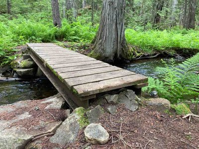

52807__AST_EX_20220707_125637.jpeg

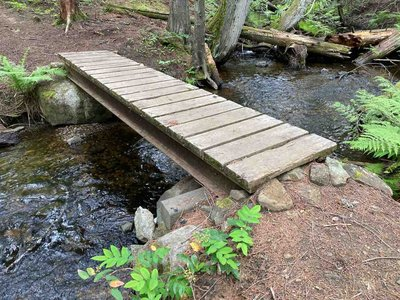

52809__AST_EX_20220707_125254.jpeg

Asset 50654 2 images

Predicted: VLM: Beam | DINOv3: Beam (conf: N/A)

Actual: Beam

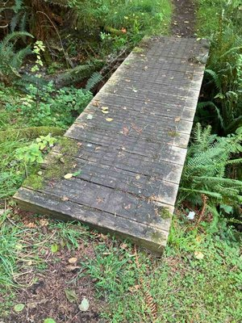

73031__AST_EX_20240830_162340.jpeg

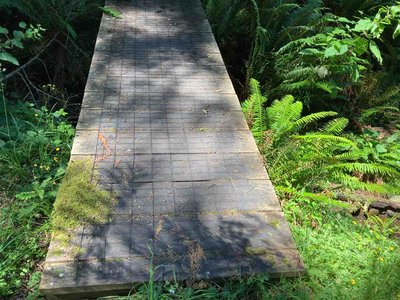

53275__AST_EX_20220712_124202.jpeg

Asset 51531 5 images

Predicted: VLM: Beam | DINOv3: Beam (conf: N/A)

Actual: Beam

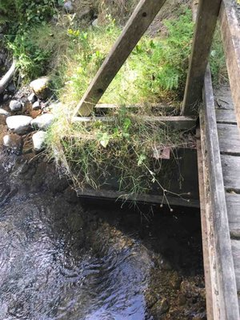

19731__AST_EX_20210902_150337.jpeg

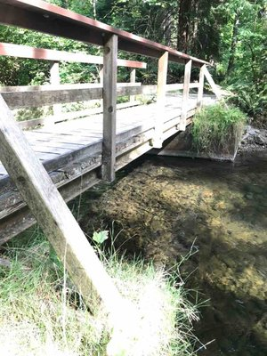

19733__AST_EX_20210902_150306.jpeg

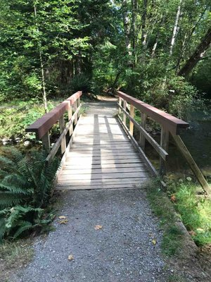

19734__AST_EX_20210902_150318.jpeg

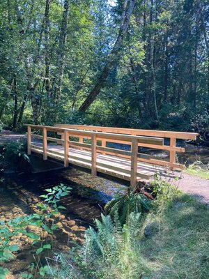

72728__AST_EX_20240821_110901.jpeg

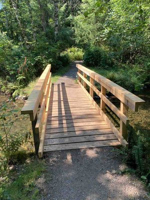

72729__AST_EX_20240821_110849.jpeg

Asset 52551 3 images

Predicted: VLM: Beam | DINOv3: Beam (conf: N/A)

Actual: Beam

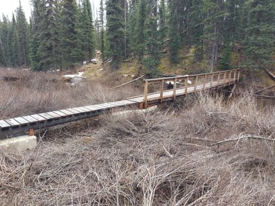

40680__20220510_131639.jpg

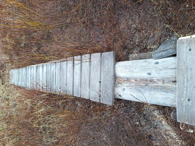

90512__20251112_103203.jpg

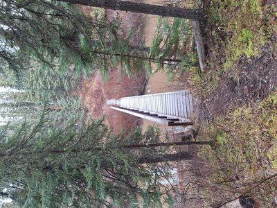

90513__20251112_103049.jpg

Asset 53798 1 image

Predicted: VLM: Beam | DINOv3: Beam (conf: N/A)

Actual: Beam

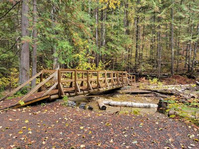

45354__Upper_Canyon_Bridge__Oct_2021_.jpeg

Asset 54324 2 images

Predicted: VLM: Suspension | DINOv3: Suspension (conf: N/A)

Actual: Suspension

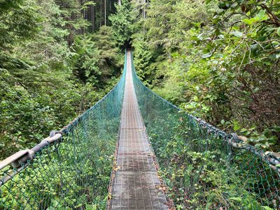

61485__AST_EX_20220826_122106.jpeg

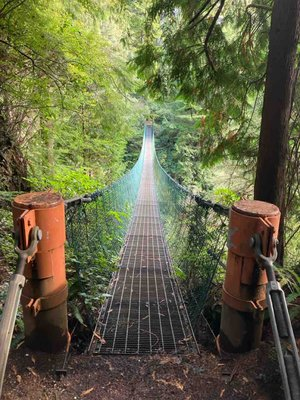

76422__AST_EX_20241024_144751.jpeg

Asset 56469 2 images

Predicted: VLM: Beam | DINOv3: Beam (conf: N/A)

Actual: Beam

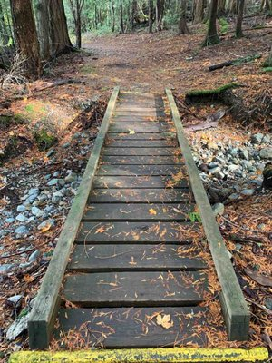

26401__AST_EX_20211013_112159.jpeg

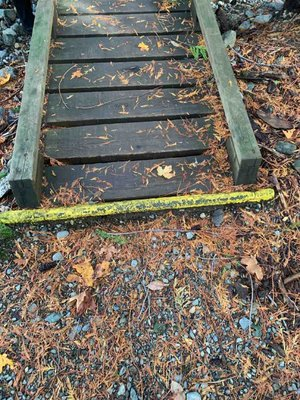

26420__AST_EX_20211013_112134.jpeg

Asset 56876 2 images

Predicted: VLM: Beam | DINOv3: Beam (conf: N/A)

Actual: Beam

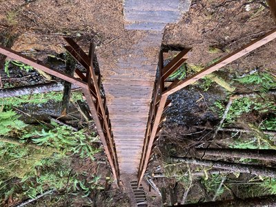

21691__IMG_0687.JPG

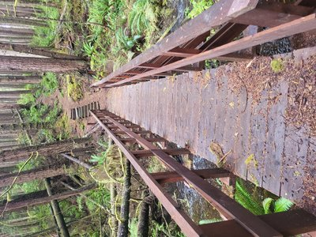

76071__s26.jpg

Asset 58162 3 images

Predicted: VLM: Beam | DINOv3: Beam (conf: N/A)

Actual: Beam

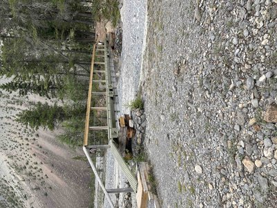

8038__AST_EX_20210725_145118.jpeg

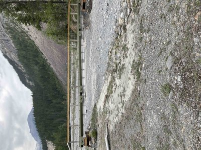

8039__AST_EX_20210725_145107.jpeg

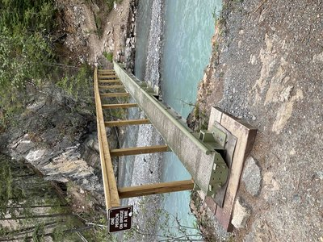

8040__AST_EX_20210725_144934.jpeg

Asset 58955 1 image

Predicted: VLM: Beam | DINOv3: Beam (conf: N/A)

Actual: Beam

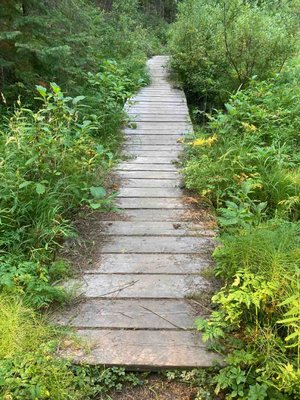

62377__AST_EX_20220901_170544.jpeg

Asset 61003 1 image

Predicted: VLM: Beam | DINOv3: Beam (conf: N/A)

Actual: Beam

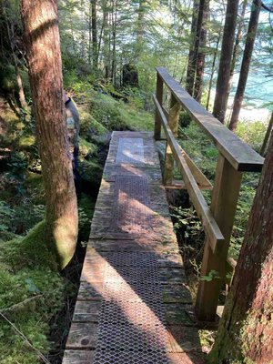

88959__AST_EX_20250924_140750.jpeg

Asset 63068 1 image

Predicted: VLM: Truss | DINOv3: Truss (conf: N/A)

Actual: Truss

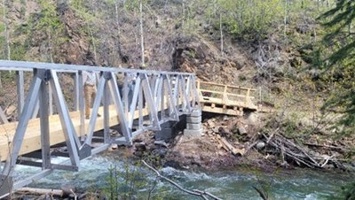

87457__Picture1.jpg

Asset 63597 1 image

Predicted: VLM: Suspension | DINOv3: Suspension (conf: N/A)

Actual: Suspension

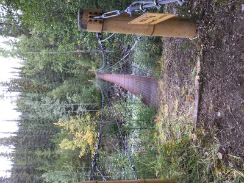

64987__IMG_0256.JPG

Asset 64643 1 image

Predicted: VLM: Beam | DINOv3: Beam (conf: N/A)

Actual: Beam

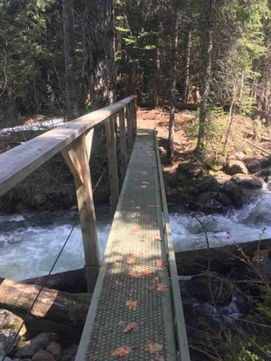

47085__AST_EX_20220617_123258.jpeg

Asset 65609 3 images

Predicted: VLM: Beam | DINOv3: Beam (conf: N/A)

Actual: Beam

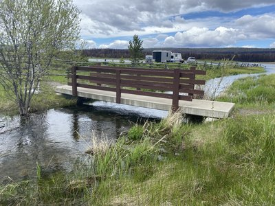

45623__IMG_0185.JPG

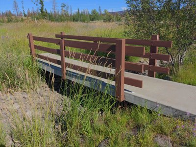

58058__MI_20220806_163737.jpg

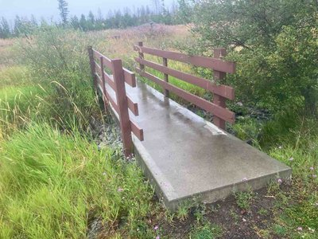

86901__AST_EX_20250815_135754.jpeg

Asset 65789 1 image

Predicted: VLM: Suspension | DINOv3: Suspension (conf: N/A)

Actual: Suspension

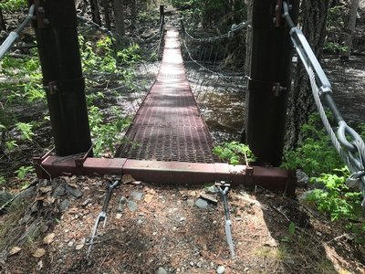

46405__Hotnarko_Suspension_Bridge_Picture_1.jpg

Asset 67205 4 images

Predicted: VLM: Beam | DINOv3: Beam (conf: N/A)

Actual: Beam

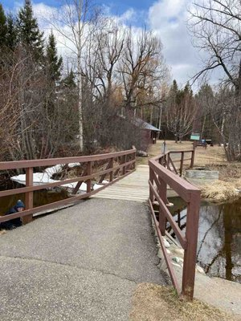

38565__AST_EX_20220331_144231.jpeg

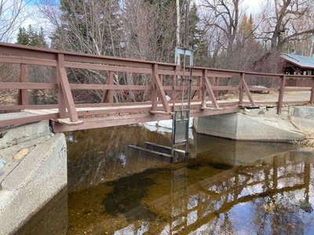

38570__AST_EX_20220331_144247.jpeg

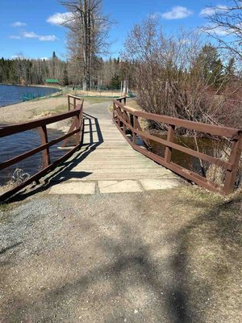

93110__AST_EX_20260422_114842.jpeg

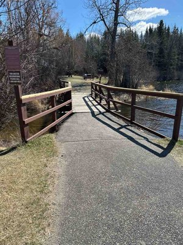

93111__AST_EX_20260422_114908.jpeg

Asset 82270 1 image

Predicted: VLM: Beam | DINOv3: Beam (conf: N/A)

Actual: Beam

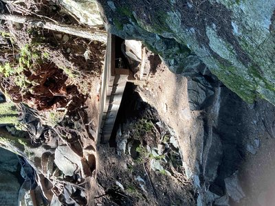

3556__AST_IM_20210630_143507.jpeg

Asset 82385 1 image

Predicted: VLM: Beam | DINOv3: Beam (conf: N/A)

Actual: Beam

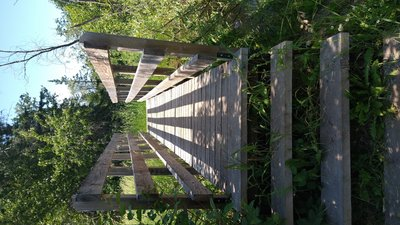

6929__MI_20210705_145854.jpg

Asset 83138 1 image

Predicted: VLM: Beam | DINOv3: Beam (conf: N/A)

Actual: Beam

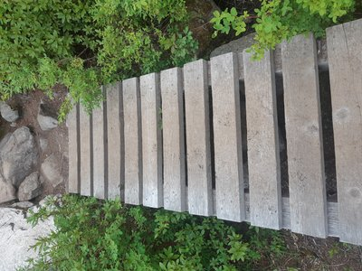

6719__MI_20210716_082223.jpg

Asset 83150 3 images

Predicted: VLM: Beam | DINOv3: Beam (conf: N/A)

Actual: Beam

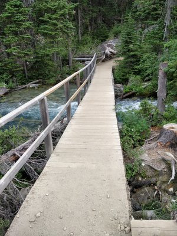

6703__MI_20210716_105250.jpg

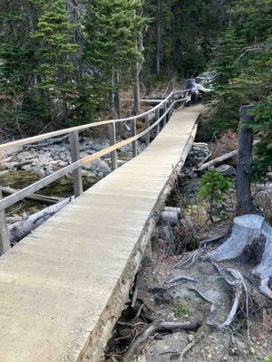

82701__AST_EX_20250525_112831.jpeg

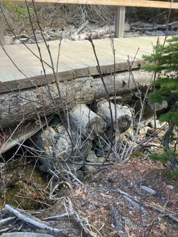

82702__AST_EX_20250525_112857.jpeg

Asset 83513 1 image

Predicted: VLM: Beam | DINOv3: Beam (conf: N/A)

Actual: Beam

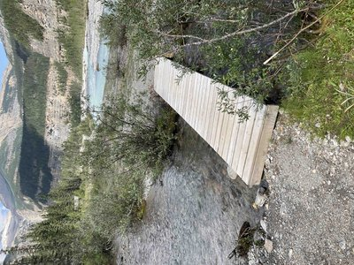

8086__AST_EX_20210727_135155.jpeg

Asset 85487 1 image

Predicted: VLM: Beam | DINOv3: Beam (conf: N/A)

Actual: Beam

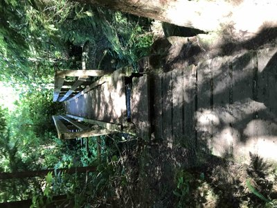

12421__AST_IM_20210804_110253.jpeg

Asset 88733 1 image

Predicted: VLM: Beam | DINOv3: Beam (conf: N/A)

Actual: Beam

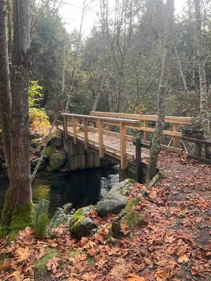

76383__AST_EX_20241024_112836.jpeg

Asset 89447 1 image

Predicted: VLM: Beam | DINOv3: Beam (conf: N/A)

Actual: Beam

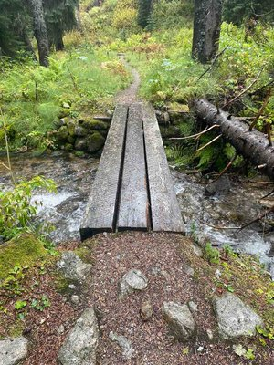

22174__AST_IM_20210918_121110.jpeg

Asset 89450 1 image

Predicted: VLM: Beam | DINOv3: Beam (conf: N/A)

Actual: Beam

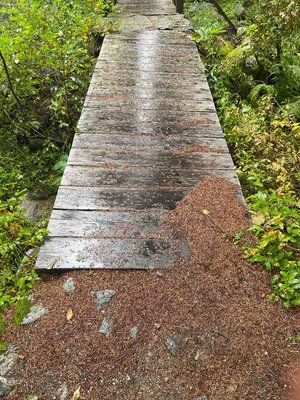

22183__AST_IM_20210918_115908.jpeg

Asset 89580 1 image

Predicted: VLM: Beam | DINOv3: Beam (conf: N/A)

Actual: Beam

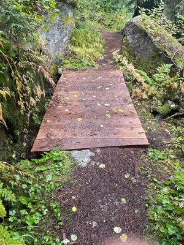

22595__AST_IM_20210919_104037.jpeg

Asset 89761 6 images

Predicted: VLM: Beam | DINOv3: Beam (conf: N/A)

Actual: Beam

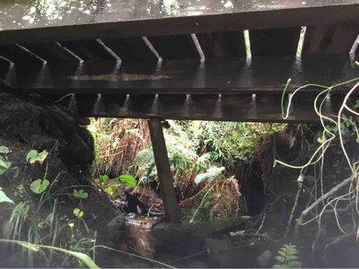

22926__AST_IM_20210921_142956.jpeg

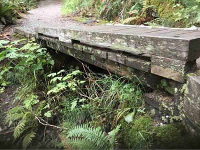

22937__AST_IM_20210921_142908.jpeg

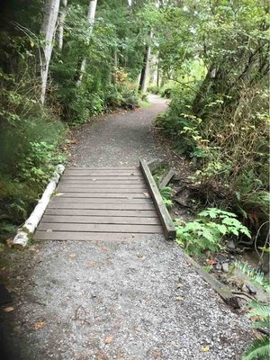

22940__AST_IM_20210921_142802.jpeg

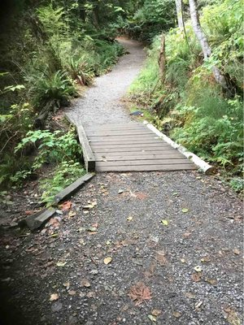

22941__AST_IM_20210921_142817.jpeg

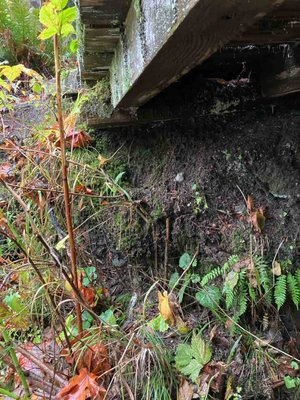

77005__AST_EX_20241106_105756.jpeg

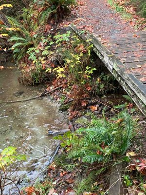

77007__AST_EX_20241106_105853.jpeg

Asset 90361 1 image

Predicted: VLM: Beam | DINOv3: Beam (conf: N/A)

Actual: Beam

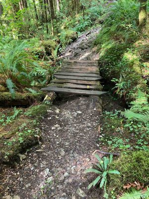

23742__AST_IM_20210922_141138.jpeg

Asset 90408 2 images

Predicted: VLM: Beam | DINOv3: Beam (conf: N/A)

Actual: Beam

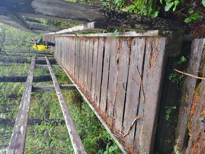

77386__20241106_122402.jpg

Asset 92164 1 image

Predicted: VLM: Beam | DINOv3: Beam (conf: N/A)

Actual: Beam

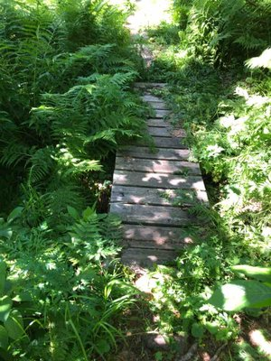

56111__AST_EX_20220725_113304.jpeg

Asset 92794 1 image

Predicted: VLM: Beam | DINOv3: Beam (conf: N/A)